# PLM Coursera WriteUp

Frank Hasbani

Saturday, November 22, 2014

# PLM Project

## Background

Using devices such as Jawbone Up, Nike FuelBand, and Fitbit it is now possible to collect a large amount of data about personal activity relatively inexpensively. These type of devices are part of the quantified self movement - a group of enthusiasts who take measurements about themselves regularly to improve their health, to find patterns in their behavior, or because they are tech geeks. One thing that people regularly do is quantify how much of a particular activity they do, but they rarely quantify how well they do it. In this project, your goal will be to use data from accelerometers on the belt, forearm, arm, and dumbell of 6 participants. They were asked to perform barbell lifts correctly and incorrectly in 5 different ways. More information is available from the website here: http://groupware.les.inf.puc-rio.br/har (see the section on the Weight Lifting Exercise Dataset).

## Executive Summary

The objective of this project is to build a Machine Learning Model that predicts the ‘classe’ of excercises that an individual followed, based on their captured activity quality from their individual monitors. The “classe” variable is one provided in the training set to help train the Model. We use any of the other variables to predict with. This report describes how we built this Model, how we used cross validation, what we think the expected out of sample error is, and why the basis on which we made the choices to build it. As a proof of suucessful prediction, we will also use the same prediction model to predict 20 different test cases.

### Loading the Data

The training data for this project are available here: https://d396qusza40orc.cloudfront.net/predmachlearn/pml-training.csv

The test data are available here: https://d396qusza40orc.cloudfront.net/predmachlearn/pml-testing.csv

We load the needed libraries, check is the Training and Testing files already exist, otherwise we download them from the source. Also in this process, we reset all of the “#DIV/0!”, “”, " “, values in the data to”NA:

```r
library(caret); library(ISLR); library(ggplot2); library(rgl); library(rpart);library(randomForest);library(corrplot); library(randomForest); library(rpart.plot); library(prodlim); library(tree); library(knitr)
##Download the data and read into file

if (!file.exists("pml-Training.csv")) {
     download.file("http://d396qusza40orc.cloudfront.net/predmachlearn/pml-training.csv",
                   destfile = "pml-Training.csv")
}
if (!file.exists("pml-Testing.csv")) {
     download.file("http://d396qusza40orc.cloudfront.net/predmachlearn/pml-testing.csv",
                   destfile = "pml-Testing.csv")
}
## Save files and format NAs

training <- read.table("pml-training.csv", header=T, sep=",", na.strings = c("#DIV/0!", "", " ", "NA"))
testing <- read.csv("pml-Testing.csv", header = T, na.strings = c("#DIV/0!", "", " ", "NA"))
```

The resulting tables are of the following dimensions:

```
## [1] 19622   160
```

```
## [1]  20 160
```

### Cleansing the Data

Clean ALL of the data sets of NAs, eliminate Zero Sums, and remove character Columns such as (“X”,“user_name”,“raw_timestamp_part_1”,“raw_timestamp_part_2”,“cvtd_timestamp”,“new_window” “windows) etc..:

### Exploratory Analysis

Correlation :

```
## [1] 14718    53
```

```
## [1] 4904   53
```

```
## [1] 20 53
```

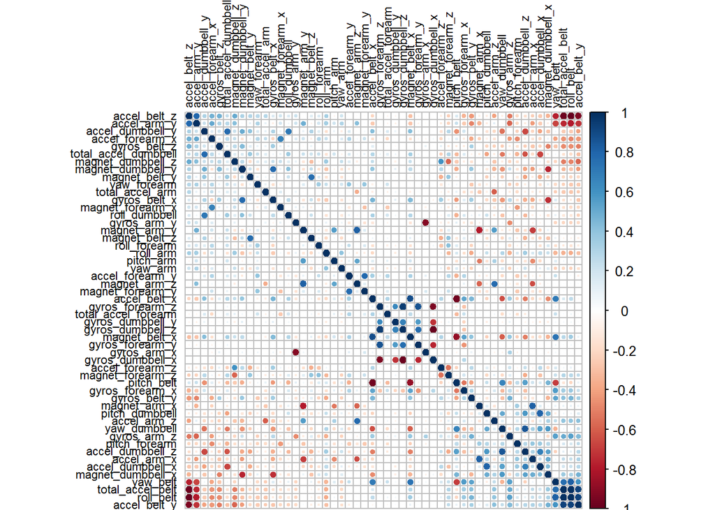

Principal Component Analysis :

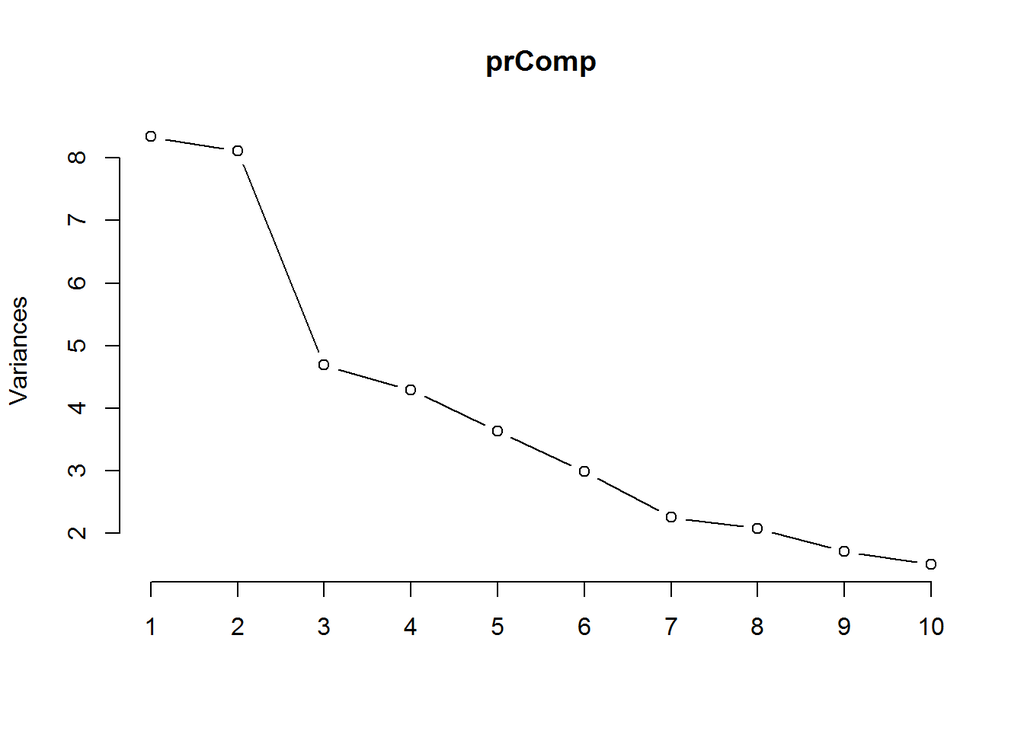

```r
# obtain the principal components of the training set
prComp<-prcomp(trSet[, -53], center = T, scale = T, newdata = valSet)
# view the amount of varaiblity explained by the principal components

plot(prComp, type="lines", main="prComp")
```

### Building the Model

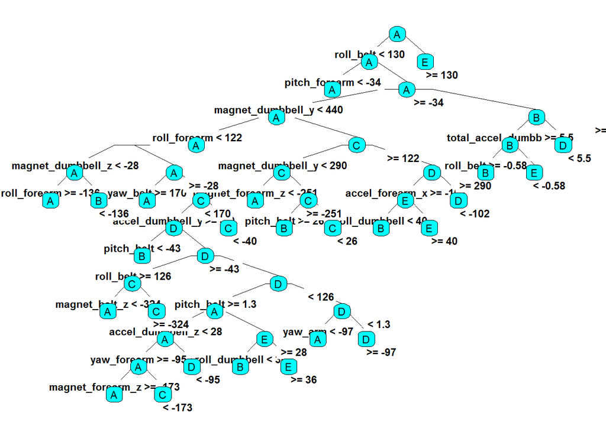

```r
#
set.seed(1975)
# ctrl <- trainControl(method="cv", number=5, allowParallel = TRUE)
# rpart Model
rpartModel <- rpart(trSet$classe~., data=trSet[, -53], control=rpart.control(cp=0.01))
prp(rpartModel, type = 4, box.col=5, leaf.round=1, tweak = 2, compress = TRUE)
```

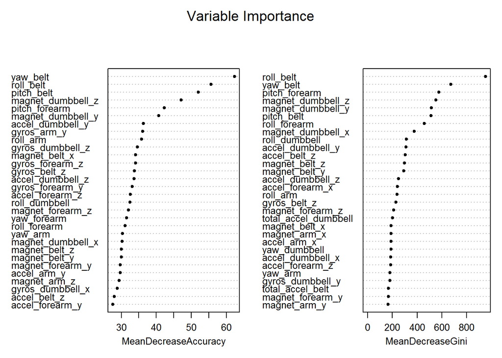

```r
# randomForest Model
rfModel <- randomForest(classe ~ ., data = trSet, proximity = T, importance = T)
varImpPlot(rfModel, pch = 20, cex = 0.8, main =  "Variable Importance" )
```

```r
###################################################################################################
# This code below was abandonned due to slow processing without producing an improved results
# rpModel <- train(trSet$classe~., data=trSet[, -53], method = "rpart", preProcess = c("center", "scale"), trControl = ctrl, tuneLength = 3)
# predictionRp<- predict(rpModel, valSet, type = "raw")
# confusionMatrix(predictionRp, valSet$classe)
# PRp$overall[1:2]
# print(PRp)
# rfModel <- train(trSet$classe ~ ., data = trSet[, -53], method = "rf", trControl = ctrl, tuneLength = 3)
#
# predictionRF <- predict(rfModel, newdata = valSet, type = "raw")
# PRf<-(confusionMatrix(predictionRF, valSet$classe))
# print(PRf[2:3])
#########################################################################################################
```

### Cross Validating the Model

```r
#####  rpart Model
rpartPredict <- predict(rpartModel, valSet, type = "class")
PRpart <- confusionMatrix(rpartPredict, valSet$classe)
#####  randomForest Model
predictionRF <- predict(rfModel, newdata = valSet, type = "class")
prf<-(confusionMatrix(predictionRF, valSet$classe))
```

```r
PRpart$overall
```

```
##       Accuracy          Kappa  AccuracyLower  AccuracyUpper   AccuracyNull
##   7.538744e-01   6.881138e-01   7.415675e-01   7.658783e-01   2.844617e-01
## AccuracyPValue  McnemarPValue
##   0.000000e+00   1.305102e-31
```

```r
# print(PRpart)
print(prf[2:3])
```

```
## $table
##           Reference
## Prediction    A    B    C    D    E
##          A 1395    4    0    0    0
##          B    0  939    5    0    0
##          C    0    6  850   13    3
##          D    0    0    0  791    1
##          E    0    0    0    0  897
##
## $overall
##       Accuracy          Kappa  AccuracyLower  AccuracyUpper   AccuracyNull
##      0.9934747      0.9917455      0.9908006      0.9955326      0.2844617
## AccuracyPValue  McnemarPValue
##      0.0000000            NaN
```

### The Best Model Selection Decision

Our Test data set comprises 20 cases. Considering the size of the dataset, none if any of the test samples will be missclassified.

```r
# Renaming the selected model to model2
model2<-rfModel
```

### The Model Submission

- predict outcome levels on the original Testing data set using Random Forest algorithm
- create the 20 files for the Submission

```r
predictfinal <- predict(model2, testingset, type="class")
predictfinal
```

```
##  1  2  3  4  5  6  7  8  9 10 11 12 13 14 15 16 17 18 19 20
##  B  A  B  A  A  E  D  B  A  A  B  C  B  A  E  E  A  B  B  B
## Levels: A B C D E
```

```r
pml_write_files = function(x){
  n = length(x)
  for(i in 1:n){
    filename = paste0("problem_id_",i,".txt")
    write.table(x[i],file=filename,quote=FALSE,row.names=FALSE,col.names=FALSE)
  }
}

pml_write_files(predictfinal)
```